# What’s in a realist’s head?

uncovering Aristotle and Locke’s way of thinking

Ferra Suryani | fks2114

# 1 Introduction

This project will dive deep into two key Realism philosophers’ thoughts - Aristotle and Locke. Realism is a school within 10 philosophy schools that emphasizes on “reality, knowledge, and value exist independent of the human mind”. These thoughts can be investigated by analyzing the text, broken down into sentences, used in both of their works.

Context: Realists argue for the use of the senses and scientific investigation in order to discover truth. The application of the scientific method also allows individuals to classify things into different groups based on their essential differences.

# 2 Preliminaries

## 2.1 libraries load

```r
library(tidyverse)
```

```r
library(tidytext)
library(stringr)
library(DT)
library(igraph)
library(ggraph)
library(topicmodels)
library('wordcloud')
library(caret)
library(ggthemes)
library(dplyr)
library(SnowballC)
library(magrittr)
library(forcats)
library(tm)
library(topicmodels)
```

## 2.2 load in data

```r
df <- read.csv("/Users/ferratan/Documents/fall2022-project1-ferrasuryani98/data/philosophy_data.csv")

# filter to only return works by Aristotle and Locke
realist <- df %>%
            filter(author == 'Aristotle' | author == 'Locke')

realist %>% as_tibble()
```

```
## # A tibble: 57,664 × 11
##    title              author school sentence_spacy sentence_str original_public…
##    <chr>              <chr>  <chr>  <chr>          <chr>                   <int>
##  1 Aristotle - Compl… Arist… arist… " When things… " When thin…             -320
##  2 Aristotle - Compl… Arist… arist… "Thus, for ex… "Thus, for …             -320
##  3 Aristotle - Compl… Arist… arist… "These have o… "These have…             -320
##  4 Aristotle - Compl… Arist… arist… "When things … "When thing…             -320
##  5 Aristotle - Compl… Arist… arist… "Thus, for ex… "Thus, for …             -320
##  6 Aristotle - Compl… Arist… arist… "Each of thes… "Each of th…             -320
##  7 Aristotle - Compl… Arist… arist… "one will giv… "one will g…             -320
##  8 Aristotle - Compl… Arist… arist… "When things … "When thing…             -320
##  9 Aristotle - Compl… Arist… arist… "Thus, for ex… "Thus, for …             -320
## 10 Aristotle - Compl… Arist… arist… "Of things th… "Of things …             -320
## # … with 57,654 more rows, and 5 more variables: corpus_edition_date <int>,
## #   sentence_length <int>, sentence_lowered <chr>, tokenized_txt <chr>,
## #   lemmatized_str <chr>
```

## 2.3 data cleaning

### 2.3.1 remove punctuation

```r
realist$sentence_cleaned <- removePunctuation(realist$sentence_lowered)

realist %>% as_tibble()
```

```
## # A tibble: 57,664 × 12
##    title              author school sentence_spacy sentence_str original_public…
##    <chr>              <chr>  <chr>  <chr>          <chr>                   <int>
##  1 Aristotle - Compl… Arist… arist… " When things… " When thin…             -320
##  2 Aristotle - Compl… Arist… arist… "Thus, for ex… "Thus, for …             -320
##  3 Aristotle - Compl… Arist… arist… "These have o… "These have…             -320
##  4 Aristotle - Compl… Arist… arist… "When things … "When thing…             -320
##  5 Aristotle - Compl… Arist… arist… "Thus, for ex… "Thus, for …             -320
##  6 Aristotle - Compl… Arist… arist… "Each of thes… "Each of th…             -320
##  7 Aristotle - Compl… Arist… arist… "one will giv… "one will g…             -320
##  8 Aristotle - Compl… Arist… arist… "When things … "When thing…             -320
##  9 Aristotle - Compl… Arist… arist… "Thus, for ex… "Thus, for …             -320
## 10 Aristotle - Compl… Arist… arist… "Of things th… "Of things …             -320
## # … with 57,654 more rows, and 6 more variables: corpus_edition_date <int>,
## #   sentence_length <int>, sentence_lowered <chr>, tokenized_txt <chr>,
## #   lemmatized_str <chr>, sentence_cleaned <chr>
```

### 2.3.2 remove stopwords

```r
realist_df <- realist %>%
  select(author, sentence_cleaned)

sw <- stop_words$word

remove_words_from_text <- function(text) {
  text <- unlist(strsplit(text, " "))
  paste(text[!text %in% sw], collapse = " ")
}

realist_df$sentence_cleaned <- lapply(realist_df$sentence_cleaned, remove_words_from_text)
```

# 3 Who has more notable works?

In this section, I’d want to see the distribution of the amount of works by each philosopher contained in the dataset. It was found that Aristotle has 48779 sentences and Locke has 8885 sentences used in each respective works.

## 3.1 number of sentences used based off author’s works

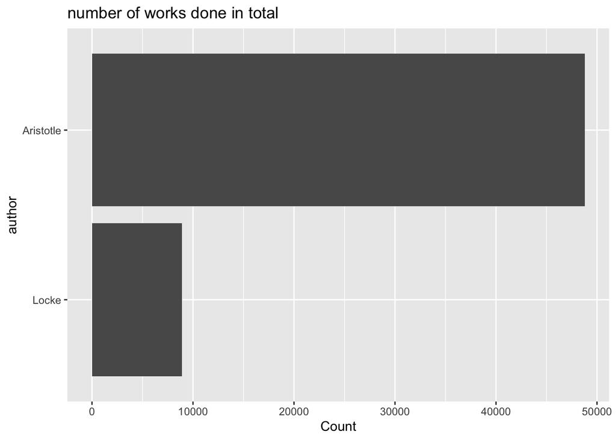

```r
realist %>%
  group_by(author) %>%
  summarise(Count = n()) %>%
  arrange(desc(Count)) %>%
  ungroup() %>%
  mutate(author = reorder(author,Count)) %>%
  ggplot(aes(x = author,y = Count)) +
  geom_bar(stat='identity') +
  labs(x = 'author',
       title = 'number of works done in total') +
  coord_flip()
```

# 4 Wordcloud: what are the 20 most common words used in each author’s works?

In this step, I’m interested in finding out the most commonly used words contained in the philosopher’s works.

## 4.1 most commonly used words in each respective works

```r
# count number of words
realist_words <- realist_df %>%
  unnest_tokens(word, sentence_cleaned) %>%
  count(author, word, sort = TRUE)

total_words <- realist_words %>%
  group_by(author) %>%
  summarize(total = sum(n))

realist_words <- left_join(realist_words, total_words)
head(realist_words)
```

```
##      author    word    n  total
## 1 Aristotle animals 2530 392748
## 2     Locke   ideas 2463  93999
## 3 Aristotle    time 2379 392748
## 4 Aristotle    body 2048 392748
## 5 Aristotle  nature 2039 392748
## 6 Aristotle  motion 1912 392748
```

## 4.2 20 common words used by Aristotle

Philosophy, to Aristotle, meant applying reason to observation as a means of understanding the riddles of our world and making the most of our lives. Aristotle is also an important contributor to some major philosophy areas such as logic, rhetoric, ethics, to name a few. As a big contributor to rhetoric, Aristotle likes to use real things to describe his viewpoint with words such as animals, nature, body, time, and water.

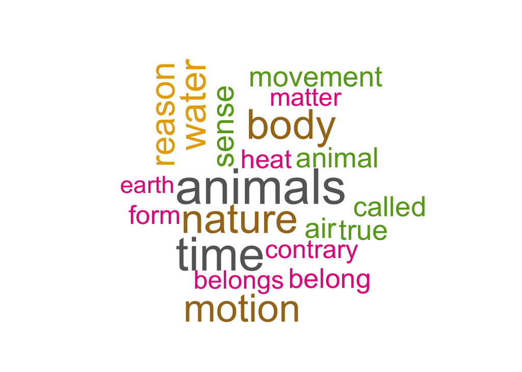

```r
# create df to return only works by Aristotle
realist_aristotle <- realist_df %>%
  select(author, sentence_cleaned) %>%
  filter(author == 'Aristotle')

# tokenize and count words
realist_aristotle %>%
  unnest_tokens(word, sentence_cleaned) %>%
  filter(!is.na(word)) %>%
  filter(!word %in% stop_words$word) %>%
  count(word,sort = TRUE) %>%
  ungroup()  %>%
  head(20) %>%

# word cloud
with(wordcloud(word, n, max.words = 20,colors=brewer.pal(8, "Dark2")))
```

## 4.3 20 common words used by Locke

Locke’s works are mainly centered around political philosophy, governmental, and education. Based off the wordcloud, it appears that ideas, idea, mind, knowledge, and power are some of the key words used in his works. These words are all major words surrounding politics and governments.

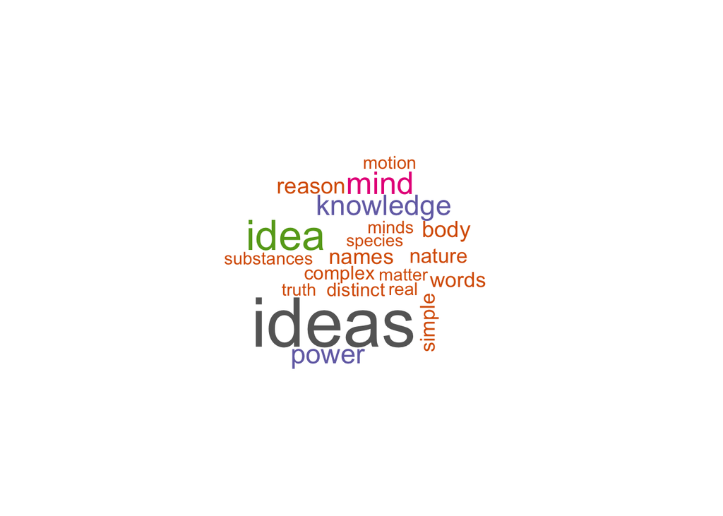

```r
# create df to return only works by Locke
realist_locke <- realist_df %>%
  select(author, sentence_cleaned) %>%
  filter(author == 'Locke')

# tokenize and count words
realist_locke %>%
  unnest_tokens(word, sentence_cleaned) %>%
  filter(!is.na(word)) %>%
  filter(!word %in% stop_words$word) %>%
  count(word,sort = TRUE) %>%
  ungroup()  %>%
  head(20) %>%

# word cloud
with(wordcloud(word, n, max.words = 20,colors=brewer.pal(8, "Dark2")))
```

# 5 TF-IDF: analyzing 15 most important words and words frequency

I’m intrigued to find out the most valuable words used in the works by each author. I’d be using the TF-IDF approach, which is a technique used to find the important words for the content of each document by decreasing the weight for commonly used words and increasing the weight for words that are not used very much in a collection or corpus of documents.

Documents in this case would be a set of words in the sentences of the works.

## 5.1 compute top 15 words by each author based off TF-IDF score

From the graph we can see that the list of words is pretty different as compared to the list of the common words. We can conclude that although Aristotle liked to use words based off various objects such as animals, nature, and body, it does not necessarily reflect the main idea of the entire work.

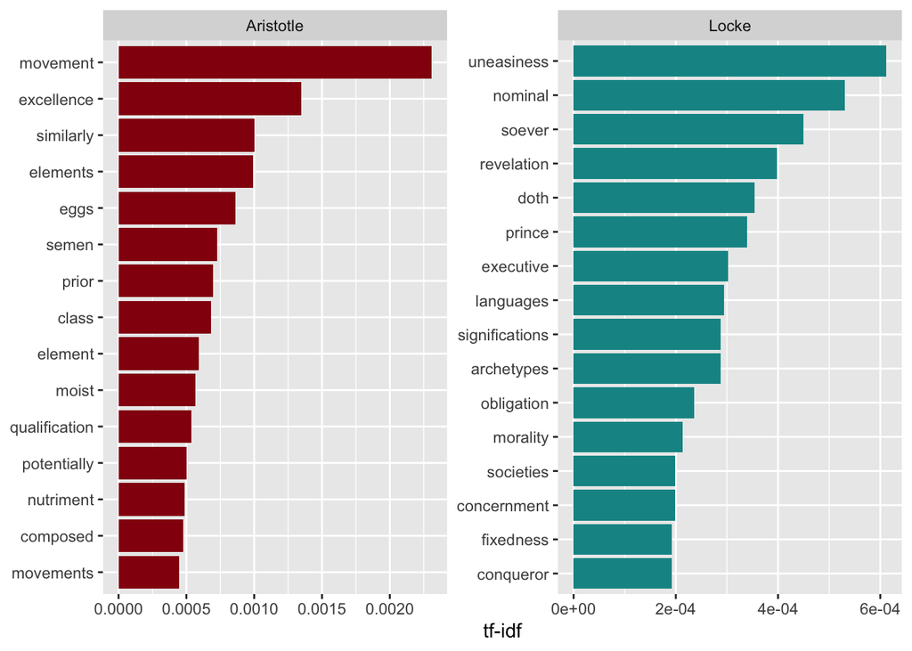

```r
# compute the tf-idf for each term
realist_words_full <- realist_words %>%
  bind_tf_idf(word, author, n)

# compute comparison graph
realist_words_full %>%
  group_by(author) %>%
  slice_max(tf_idf, n = 15) %>%
  ungroup() %>%
  ggplot(aes(tf_idf, fct_reorder(word, tf_idf), fill = author)) +
  geom_col(show.legend = FALSE) +
  scale_fill_manual(values = c("#940f0f", "#0f9494")) +
  facet_wrap(~author, ncol = 2, scales = "free") +
  labs(x = "tf-idf", y = NULL)
```

# 6 Which works do these important words belong to?

Here we dive into the works by both author that contains the important words.

## 6.1 works that contains the word ‘Movement’ in Aristotle’s works

```r
keyword_a <- "movement"

movement_works <- realist %>%
  filter(author == 'Aristotle') %>%
  filter(str_detect(sentence_lowered, keyword_a)) %>%
  select(author, sentence_lowered) %>%
  head(10)

movement_works %>% as_tibble()
```

```
## # A tibble: 10 × 2
##    author    sentence_lowered
##    <chr>     <chr>
##  1 Aristotle further, an example also makes it clear that the conclusion will n…
##  2 Aristotle try the terms movement, animal, white.
##  3 Aristotle moreover, in cases where it is possible to divide the accident eit…
##  4 Aristotle moreover, if it is possible for the genus stated, or for its diffe…
##  5 Aristotle again, see if he has placed what is a state inside the genus activ…
##  6 Aristotle again, see if they say that an affection is that of which it is an…
##  7 Aristotle now since it seems that if what is musical, in being musical, poss…
##  8 Aristotle or again, people sometimes define night as a shadow on the earth, …
##  9 Aristotle for a movement of the earth does not constitute an earthquake, nor…
## 10 Aristotle this is what happens to dionysius' definition of life when stated …
```

## 6.2 works that contains the word ‘Uneasiness’ in Locke’s works

```r
keyword_l <- "uneasiness"

uneasiness_works <- realist %>%
  filter(author == 'Locke') %>%
  filter(str_detect(sentence_lowered, keyword_l)) %>%
  select(author, sentence_lowered) %>%
  head(10)

uneasiness_works %>% as_tibble()
```

```
## # A tibble: 10 × 2
##    author sentence_lowered
##    <chr>  <chr>
##  1 Locke  the term here i use in a large sense, as comprehending not barely the…
##  2 Locke  delight or uneasiness, one or other of them, join themselves to almos…
##  3 Locke  , on the one side, or uneasiness, trouble, pain, torment, anguish, mi…
##  4 Locke  , the other, they are still but different degrees of the same thing, …
##  5 Locke  but hatred or love, to beings capable of happiness or misery, is ofte…
##  6 Locke  the uneasiness a man finds in himself upon the absence of anything wh…
##  7 Locke  for whatsoever good is proposed, if its absence carries no displeasur…
##  8 Locke  desire also is stopped or abated by the opinion of the impossibility …
##  9 Locke  is uneasiness in the mind, upon the thought of a good lost, which mig…
## 10 Locke  is an uneasiness of the mind, upon the thought of future evil likely …
```

# 7 Most common bigram

A bigram is a collection of two words. This step involves approaches to unveil a pair of words rather than individual words.

## 7.1 tokenizing by bigram: Aristotle

```r
# create bigram
realist_bigram_aristotle <- realist_aristotle %>%
  unnest_tokens(bigram, sentence_cleaned, token = "ngrams", n = 2)

head(realist_bigram_aristotle)
```

```
##      author                 bigram
## 1 Aristotle      common definition
## 2 Aristotle definition corresponds
## 3 Aristotle     corresponds called
## 4 Aristotle      called homonymous
## 5 Aristotle        picture animals
## 6 Aristotle      common definition
```

```r
# count and filter bigram
realist_bigram_aristotle %>%
  count(bigram, sort = TRUE) %>%
  head(20)
```

```
##                 bigram    n
## 1                 <NA> 1969
## 2          male female  165
## 3          middle term  151
## 4       belongs belong  146
## 5        motion motion  134
## 6      belongs belongs  118
## 7        belong belong  117
## 8     makes difference  112
## 9           true false  112
## 10       straight line  110
## 11           air water  109
## 12         white white  107
## 13            hot cold  104
## 14    practical wisdom  103
## 15         white black   93
## 16           water air   92
## 17           time time   88
## 18    sense perception   85
## 19  sexual intercourse   85
## 20 sanguineous animals   83
```

## 7.2 tokenizing by bigram: Locke

```r
# create bigram
realist_bigram_locke <- realist_locke %>%
  unnest_tokens(bigram, sentence_cleaned, token = "ngrams", n = 2)

head(realist_bigram_locke, 20)
```

```
##    author               bigram
## 1   Locke          reader thou
## 2   Locke            thou hast
## 3   Locke       hast beginning
## 4   Locke  beginning discourse
## 5   Locke discourse government
## 6   Locke      government fate
## 7   Locke        fate disposed
## 8   Locke      disposed papers
## 9   Locke        papers filled
## 10  Locke        filled middle
## 11  Locke          middle rest
## 12  Locke           rest worth
## 13  Locke           worth thee
## 14  Locke          remain hope
## 15  Locke      hope sufficient
## 16  Locke sufficient establish
## 17  Locke     establish throne
## 18  Locke      throne restorer
## 19  Locke        restorer king
## 20  Locke         king william
```

```r
# count and filter bigram
realist_bigram_locke %>%
  count(bigram, sort = TRUE) %>%
  head(20)
```

```
##                    bigram   n
## 1            simple ideas 354
## 2                    <NA> 304
## 3            complex idea 184
## 4           complex ideas 177
## 5  agreement disagreement 131
## 6          distinct ideas 104
## 7             mixed modes  93
## 8          abstract ideas  82
## 9        ideas substances  81
## 10             ideas mind  79
## 11           real essence  78
## 12          real essences  60
## 13     disagreement ideas  59
## 14            ideas minds  59
## 15            ideas names  59
## 16          pleasure pain  56
## 17             law nature  55
## 18   sensation reflection  52
## 19            simple idea  51
## 20      innate principles  48
```

## 7.3 bigram chart with most important bigrams

Based off the chart, I noticed that Aristotle used a lot more ambiguous pairing of words related to concepts, while Locke seems to be more discrete with the choice of word pairings in his works, where he used a lot of words such as mind and ideas.

```r
# combine both bigram
realist_bigram_all <- rbind(realist_bigram_aristotle, realist_bigram_locke)

# tokenized with tf-idf approach
bigram_tf_idf <- realist_bigram_all %>%
  count(author, bigram) %>%
  bind_tf_idf(bigram, author, n) %>%
  arrange(desc(tf_idf))

head(bigram_tf_idf, 10)
```

```
##    author                 bigram   n           tf       idf       tf_idf
## 1   Locke           simple ideas 354 0.0041415134 0.6931472 0.0028706783
## 2   Locke           complex idea 184 0.0021526510 0.6931472 0.0014921040
## 3   Locke          complex ideas 177 0.0020707567 0.6931472 0.0014353392
## 4   Locke agreement disagreement 131 0.0015325939 0.6931472 0.0010623132
## 5   Locke         distinct ideas 104 0.0012167158 0.6931472 0.0008433631
## 6   Locke            mixed modes  93 0.0010880247 0.6931472 0.0007541613
## 7   Locke         abstract ideas  82 0.0009593336 0.6931472 0.0006649594
## 8   Locke             ideas mind  79 0.0009242360 0.6931472 0.0006406316
## 9   Locke           real essence  78 0.0009125369 0.6931472 0.0006325223
## 10  Locke          real essences  60 0.0007019514 0.6931472 0.0004865557
```

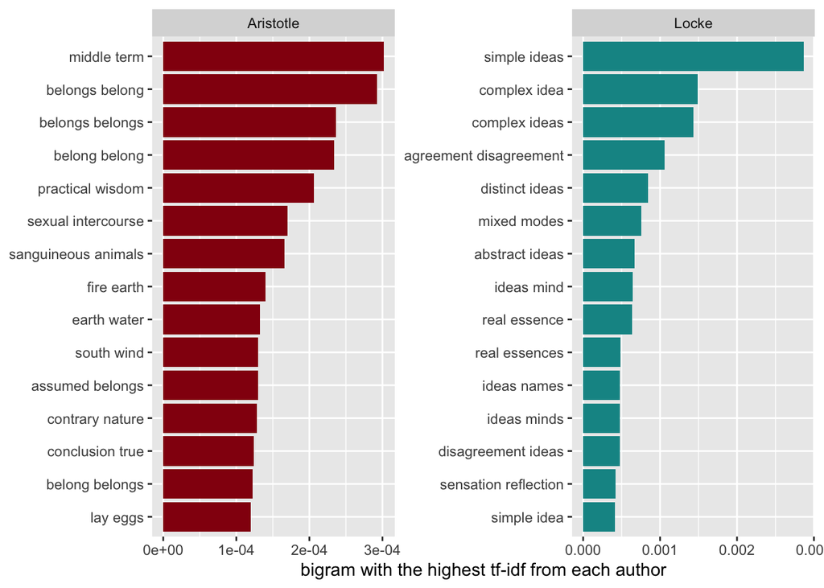

```r
# create chart
bigram_tf_idf %>%
  group_by(author) %>%
  slice_max(tf_idf, n = 15) %>%
  ungroup() %>%
  ggplot(aes(tf_idf, fct_reorder(bigram, tf_idf), fill = author)) +
  geom_col(show.legend = FALSE) +
  scale_fill_manual(values = c("#940f0f", "#0f9494")) +
  facet_wrap(~author, ncol = 2, scales = "free") +
  labs(x = "bigram with the highest tf-idf from each author", y = NULL)
```

# 8 Relationships among important words

This particular step will unwrap the visualization of all the relationships among words by building a network graph, which makes up of a combination of connected nodes containing words that appeared at least 50 times.

## 8.1 common bigrams by Aristotle

The visualization showcases a good way to see the text structure and that the word pairings seem to be pretty scattered. Since Aristotle’s works are known to be heavily inspired by looking from the perspectives of various objects around the world, the word chains mainly come from those objects, as seen from various elements such as “water”, “earth”, “fire” and also a group of word chains including “heat”, “cold”, “hot” to represent temperatures.

```r
# separate bigram into two words and count each word
bigram_counts_a <- realist_aristotle %>%
    unnest_tokens(bigram, sentence_cleaned, token = "ngrams", n = 2) %>%
    separate(bigram, c("word1", "word2"), sep = " ") %>%
    filter(!word1 %in% stop_words$word,
           !word2 %in% stop_words$word) %>%
    count(word1, word2, sort = TRUE)

head(bigram_counts_a, 10)
```

```
##       word1      word2    n
## 1      <NA>       <NA> 1969
## 2      male     female  165
## 3    middle       term  151
## 4   belongs     belong  146
## 5    motion     motion  134
## 6   belongs    belongs  118
## 7    belong     belong  117
## 8     makes difference  112
## 9      true      false  112
## 10 straight       line  110
```

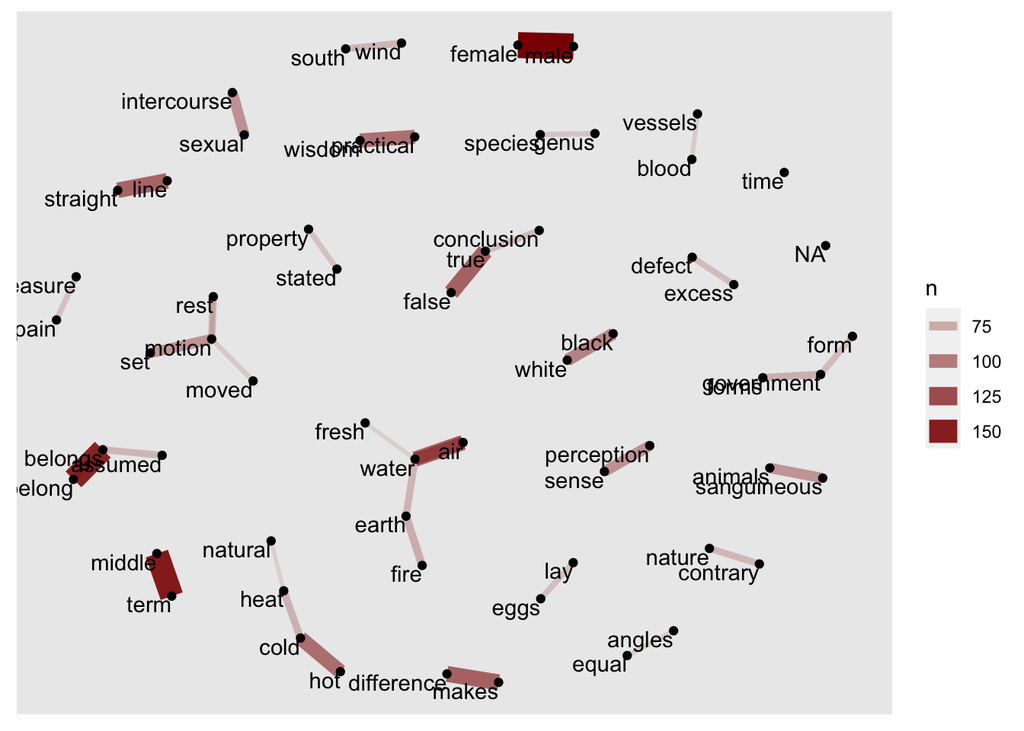

```r
# create word graph with words that appeared more than 50 times
bigram_graph_a <- bigram_counts_a %>%
  filter(n > 50) %>%
  graph_from_data_frame()
# create ggraph
library(ggraph)
set.seed(2022)

ggraph(bigram_graph_a, layout = "fr") +
  geom_edge_link(aes(edge_alpha = n, edge_width = n), edge_colour = "darkred") +
  geom_node_point() +
  geom_node_text(aes(label = name), vjust = 1, hjust = 1)
```

## 8.2 common bigrams by Locke

Locke’s choices of words are more inter-correlated to each other. This makes sense since majority of Locke’s works are more leaning towards logical perspectives such as political or education. The big word chain that involves “mind”, “ideas”, “complex”, “abstract”, “distinct” represents logical viewpoint.

```r
# separate bigram into two words and count each word
bigram_counts_l <- realist_locke %>%
    unnest_tokens(bigram, sentence_cleaned, token = "ngrams", n = 2) %>%
    separate(bigram, c("word1", "word2"), sep = " ") %>%
    filter(!word1 %in% stop_words$word,
           !word2 %in% stop_words$word) %>%
    count(word1, word2, sort = TRUE)

head(bigram_counts_l, 10)
```

```
##        word1        word2   n
## 1     simple        ideas 354
## 2       <NA>         <NA> 304
## 3    complex         idea 184
## 4    complex        ideas 177
## 5  agreement disagreement 131
## 6   distinct        ideas 104
## 7      mixed        modes  93
## 8   abstract        ideas  82
## 9      ideas   substances  81
## 10     ideas         mind  79
```

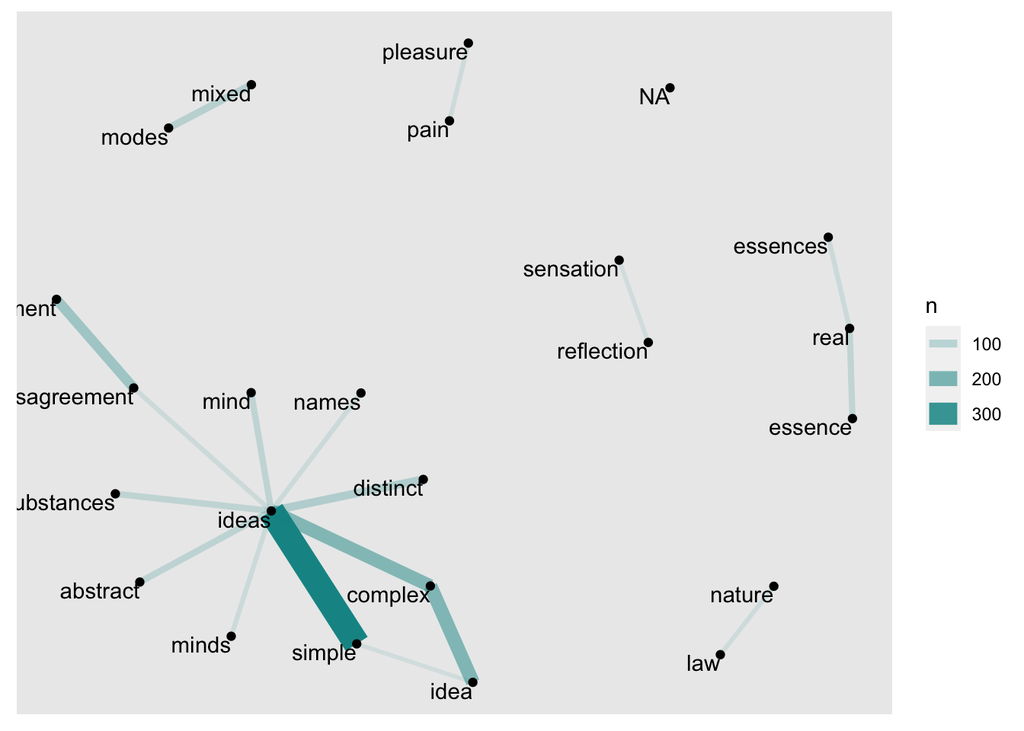

```r
# create word graph with words that appeared more than 50 times
bigram_graph_l <- bigram_counts_l %>%
  filter(n > 50) %>%
  graph_from_data_frame()
# create ggraph
set.seed(2022)

ggraph(bigram_graph_l, layout = "fr") +
  geom_edge_link(aes(edge_alpha = n, edge_width = n), edge_colour = "#0f9494") +
  geom_node_point() +
  geom_node_text(aes(label = name), vjust = 1, hjust = 1)
```

# 9 What are some words that are about equally used by both author?

In this step I’m digging into the similarity in the word usage by both author. Based off the dataframe, we can see that both author seem to involve some emotional words such as “empty”, “hatred”, “perished” and also adjectives that symbolize togetherness to convey their intended message such as “uniform” and “assembly”.

```r
tidy_realist <-realist %>%
  unnest_tokens(word, sentence_lowered) %>%
  filter(!word %in% stop_words$word,
         !word %in% str_remove_all(stop_words$word, "'"),
         str_detect(word, "[a-z]"))

word_ratios <- tidy_realist %>%
  count(word, author) %>%
  group_by(word) %>%
  filter(sum(n) >= 10) %>%
  ungroup() %>%
  pivot_wider(names_from = author, values_from = n, values_fill = 0) %>%
  mutate_if(is.numeric, list(~(. + 1) / (sum(.) + 1))) %>%
  mutate(logratio = log(Aristotle / Locke)) %>%
  arrange(desc(logratio))

# top 10 words
word_ratios %>%
  arrange(abs(logratio)) %>%
  head(10)
```

```
## # A tibble: 10 × 4
##    word     Aristotle     Locke logratio
##    <chr>        <dbl>     <dbl>    <dbl>
##  1 sound    0.000881  0.000882  -0.00186
##  2 assembly 0.000129  0.000129  -0.00302
##  3 empty    0.000199  0.000200  -0.00430
##  4 uniform  0.000199  0.000200  -0.00430
##  5 pre      0.000107  0.000106   0.00659
##  6 hatred   0.0000701 0.0000706 -0.00665
##  7 letter   0.0000701 0.0000706 -0.00665
##  8 perished 0.0000701 0.0000706 -0.00665
##  9 shape    0.000701  0.000706  -0.00665
## 10 ten      0.000292  0.000294  -0.00825
```

# 10 Which 15 words are most likely to be used by Aristotle or Locke in their respective works?

In this step we’re diving into the 15 most distinctive words used by both author. It looks like the choice of words Aristotle used primarily is more about achievements, which can be concluded from the words “excellence” and “qualification”, and also comparing two different ideas where he used words like “similarly” and “potentially”.

In Locke’s case, we can see how he focuses on political standpoint as he used words like “annexed”, “legislative”, and “executive”. He also seems to emphasize a lot of points in his works as seen from the words “certainty” and “signification”

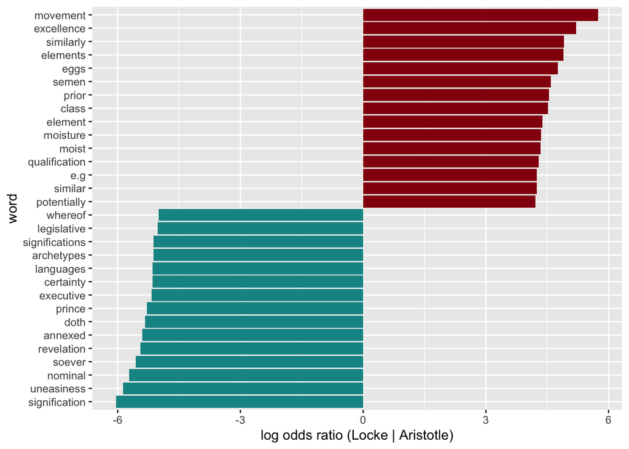

```r
word_ratios %>%
  group_by(logratio < 0) %>%
  slice_max(abs(logratio), n = 15) %>%
  ungroup() %>%
  mutate(word = reorder(word, logratio)) %>%
  ggplot(aes(word, logratio, fill = logratio < 0)) +
  geom_col(show.legend = FALSE) +
  scale_fill_manual(values = c("#940f0f", "#0f9494")) +
  coord_flip() +
  ylab("log odds ratio (Locke | Aristotle)")
```

# 11 Topic Modeling

I’m diving into what topic that each work represents using LDA approach to cluster the list of words into 4 topics in this step.

```r
# find document-word counts
doc_word_counts <- tidy_realist %>%
  anti_join(stop_words) %>%
  count(author, word, sort = TRUE)
dtm <- doc_word_counts %>%
  cast_dtm(author, word, n)

# A LDA_VEM topic model with 4 topics.
model_lda <- LDA(dtm, k = 4, control = list(seed = 2022))
model_lda
```

```
## A LDA_VEM topic model with 4 topics.
```

```r
# examine per-topic word probabiltiies
lda_beta <- tidy(model_lda, matrix = "beta")
head(lda_beta, 20)
```

```
## # A tibble: 20 × 3
##    topic term         beta
##    <int> <chr>       <dbl>
##  1     1 animals 0.00701
##  2     2 animals 0.00169
##  3     3 animals 0.00592
##  4     4 animals 0.000230
##  5     1 ideas   0.0000570
##  6     2 ideas   0.00989
##  7     3 ideas   0.0000286
##  8     4 ideas   0.0326
##  9     1 time    0.00879
## 10     2 time    0.000802
## 11     3 time    0.00345
## 12     4 time    0.00434
## 13     1 body    0.00935
## 14     2 body    0.0186
## 15     3 body    0.000542
## 16     4 body    0.00154
## 17     1 nature  0.00453
## 18     2 nature  0.000874
## 19     3 nature  0.00600
## 20     4 nature  0.00679
```

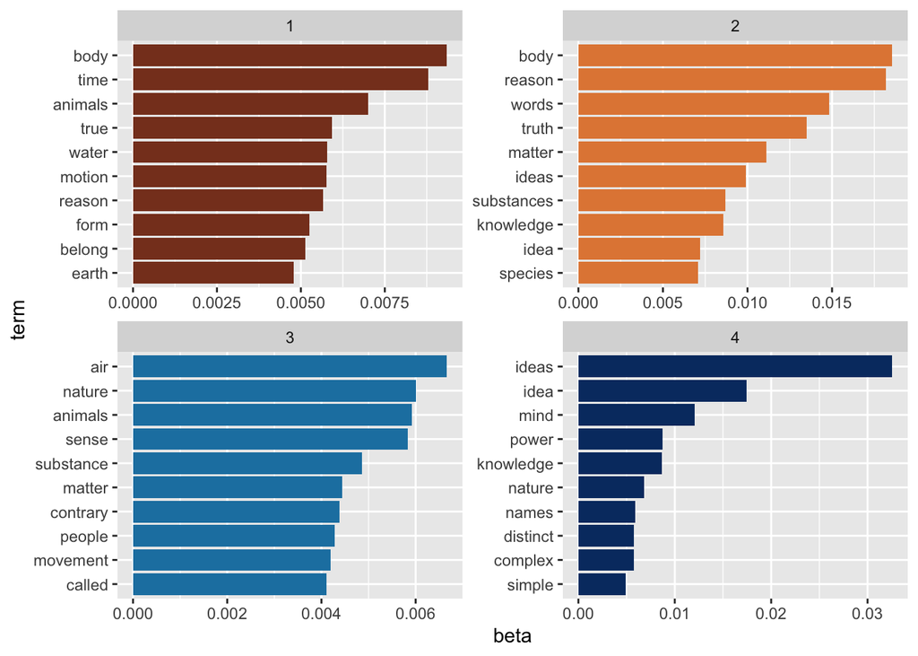

```r
# top 10 terms that are most common within each topic
lda_beta_top_terms <- lda_beta %>%
  group_by(topic) %>%
  slice_max(beta, n = 10) %>%
  ungroup() %>%
  arrange(topic, -beta)

lda_beta_top_terms %>%
  mutate(term = reorder_within(term, beta, topic)) %>%
  ggplot(aes(beta, term, fill = factor(topic))) +
  geom_col(show.legend = FALSE) +
  facet_wrap(~ topic, scales = "free") +
  scale_fill_manual(values = c("#873e23", "#e28743", "#1e81b0", "#063970")) +
  scale_y_reordered()
```

## 11.1 examine which topics are associated with which author

We can see that topic 1 and 3 are most likely to be associated with Aristotle’s works while topic 2 and 4 are most likely to be associated with Locke’s works.

Topic 1 has more words related to the nature, which aligns with Aristotle’s logical perspective of using objects to convey his messages, since it involves words such as “animals”, “water”, “earth”. Topic 3 returns a similar topic where it also contains words such as “air”, “nature”, “animals”. “people”, and “substance”.

Topic 2 and 4 contain variety of words around conceptual words such as “truth”, “knowledge”, “ideas”, “mind”, “distinct”, “complex”, and “simple”. This seems to reflect Locke’s works since he focuses more on political and educational perspectives.

```r
lda_gamma <- tidy(model_lda, matrix = "gamma")

lda_gamma %>% arrange(desc(gamma))
```

```
## # A tibble: 8 × 3
##   document  topic      gamma
##   <chr>     <int>      <dbl>
## 1 Locke         4 0.735
## 2 Aristotle     1 0.497
## 3 Aristotle     3 0.487
## 4 Locke         2 0.265
## 5 Aristotle     2 0.0154
## 6 Aristotle     4 0.000940
## 7 Locke         1 0.00000126
## 8 Locke         3 0.00000126
```